# Pacing the Meta: Un’Goro vs. Gadgetzan

The year of the Kraken will undoubtedly be remembered for being a year dominated by aggressive strategies. Cards like [Tunnel Trogg](https://www.youtube.com/watch?v=vUtjt13k9m4), Flamewreather Faceless, Flame Imp and Small-Time Buccaneer were all meta defining at one point or another, and consistently a common sight on ladder. In fact, its fair to say its been a *very* long time since Hearthstone wasn’t dominated by aggro, with decks like Face Hunter and Zoo Warlock having impact long before Standard was announced.

With the [obliteration from orbit](https://hsreplay.net/articles/5/shaking-meta-patch-71-numbers) of Aggro Shaman in patch 7.1, the rotation of three sets from Standard and the release of Journey to Un’Goro (JUG), many have speculated on the pace of the meta. Many have suggested it “feels” slower.

If your one of the people (like me) that thought the meta had slowed, the results may shock you!

### Mid-Range Everything

Figure 1: Percentage of games by final turn, class and patch. Solid lines represent the average turn the game finished. Only games that finish by turn 20 are displayed.

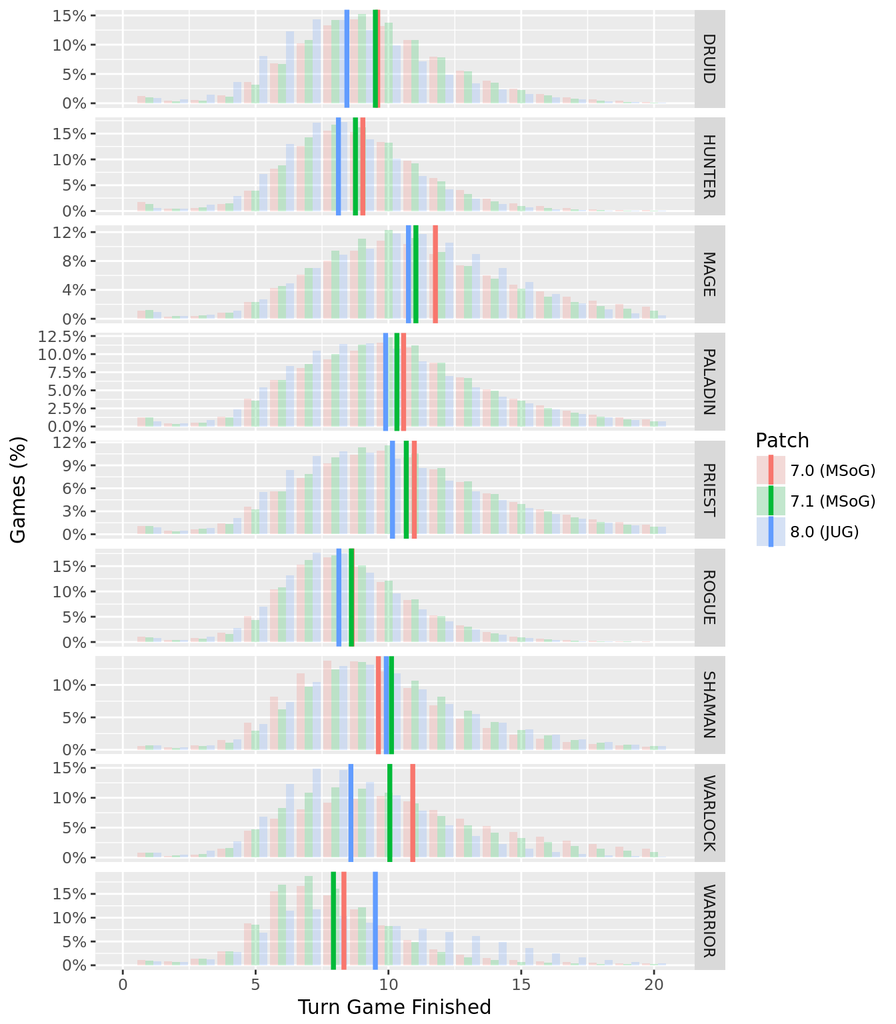

Any discussion of the pace of the meta should start with Warrior, given the effectiveness of [Pirate Warrior](https://hsreplay.net/decks/#playerClasses=WARRIOR&rankRange=LEGEND_THROUGH_TEN&includedCards=40465) in all three patches considered. The data suggests that Warrior was fastest in patch 7.1, when Control Warrior was least viable (thanks to Jade decks) and Pirate Warriors counter, Aggro Shaman, had felt the full force of Blizzards nerfs. JUG introduced a competitive new warrior archetype, [Quest (Taunt) Warrior](https://hsreplay.net/decks/#playerClasses=WARRIOR&includedCards=41427&rankRange=LEGEND_THROUGH_TEN), which slowed the class almost two full turns on average!

### So Long Fatigue

The figure below shows the pace of the meta when taken as a whole. Amazingly, matches are ending earlier with every patch, and games are currently almost a full turn shorter on average compared to February of this year!

Figure 2: Percentage of games by final turn and patch. Solid lines represent the average turn the game finished. Only games that finish by turn 20 are displayed.

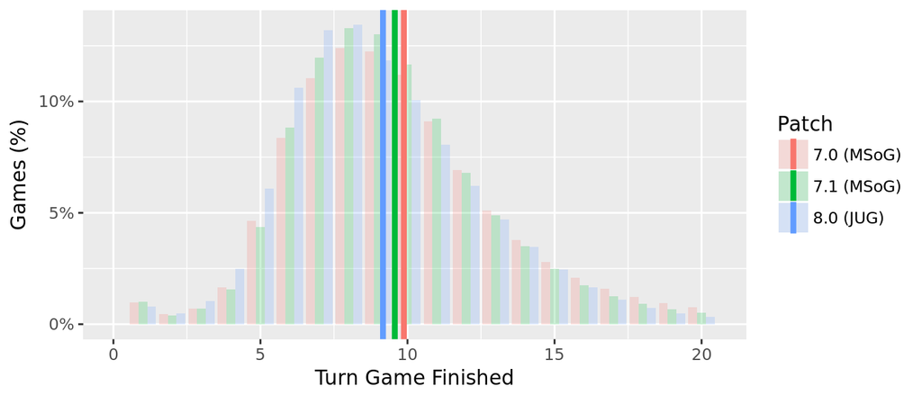

So why might the pace *feel* slower or different? A frequently expressed [critisism](https://www.youtube.com/watch?v=70x7OB_Ov0U) of the “Patches vs. Reno” era of hyper-agressive vs. hyper-defensive decks we saw in MSoG was that alot of games were decided by early game draw. Its this exact mechanic that aggro decks are designed to prey on, its why they work (on average). In JUG, no class is as fast as what Warrior was in Patch 7.1, and therefore players probably dont feel quite the same pressure to draw well in the early game.

In JUG, the quicker games are largely driven by the slower classes getting faster, rather than a dominace of aggro. Mechanics like jade and quest actively slow you in the early game but finish it quickly once your investment pays off. Classic attrition style control decks are probably a thing of the past, as Blizzard is actively designing them out of the game ([*](http://au.ign.com/articles/2017/01/13/hearthstone-blizzard-on-designing-jade-testing-red-mana-and-leaving-reno-behind), [*](https://us.battle.net/forums/en/hearthstone/topic/20752595155?page=4#post-63)). They simply cant compete with extreme value cards like Jade Idol, Drakonid Operative, Sulfurus and Nether Portal.

[“One of the things that we like in decks is for when you do your thing, the game actually ends.”](http://au.ign.com/articles/2017/01/13/hearthstone-blizzard-on-designing-jade-testing-red-mana-and-leaving-reno-behind) - Mike Donais, Senior Designer

[“We do prefer when games end before fatigue, and we do think control decks should have a more active endgame than merely having a bunch of removal spells”](https://us.battle.net/forums/en/hearthstone/topic/20752595155?page=4#post-63) - Max McCall, Game Designer

With this in mind, quests feel like a refinement of the jade mechanic. Its interesting to think of Jade Druid and Pirate Warrior as decks that had a similar purpose, to lower the number of games dragging out or reaching fatigue. Both of these decks acheived this, however the community reacted poorly to a meta defined by these two polar opposites. But with quests, Blizzard found a way to tighten the end-game in more diverse ways without players feeling like passengers in the early game. Its probably part of the reason the community has reacted so positively to the set.